# Machine Learning Final Project

## Synopsis

The goal of this project is to predict the exercise activity by studying data from accelerometers on the belt, forearm, arm, and dumbell of 6 participants in an exercise study. The participants were asked to perform barbell lifts correctly and incorrectly in 5 different ways. The variable “classe” was used in a blind study to determine which estimation approach (rpart, randomforest or gbm) would be the most accurate.

## Data Preparation Steps

First, the train and final blind data set were loaded into the variables “train_data” and “blind_test”, assuming the downloaded files are in the working directory.

```r
setwd("/Users/davidboberski/Desktop/Dad/R files/Machine Learning/")

train_data <- read.csv("pml-training.csv", na.strings=c("NA","#DIV/0!", ""))
blind_test <- read.csv("pml-testing.csv", na.strings=c("NA","#DIV/0!", ""))
```

Here the data is cleaned and prepared for analysis.

[figure not shown]

Next, the train data were split 60% into training and 40% into testing buckets using the variables “myTrain” and “myTest” respectively.

```r
library(caret)
set.seed(1)
myTrain_index <- createDataPartition(y = train_data$classe, p = 0.6, list = FALSE)
myTrain <- train_data[myTrain_index, ]
myTest <- train_data[-myTrain_index, ]
```

Remove missing values.

```r
# remove the index, user id, timestamp etc.
myTrain <- myTrain[,-(1:6)]
myTest <- myTest[,-(1:6)]
blind_test <- blind_test[,-(1:6)]

# remove the columns with all "NA"s
myTrain <- myTrain[,colSums(is.na(myTrain)) == 0]
myTest <- myTest[,colSums(is.na(myTest)) == 0]
blind_test <- blind_test[,colSums(is.na(blind_test)) == 0]
```

The five classes A-E seems to distribute reasonably even in the data set.

## Model Analysis

```r
library(randomForest)
library(rpart)
library(gbm)
library(plyr)

# 5-fold cross validation, PCA for data preprocessing, and parallel for speed up
set.seed(3)
tr_cntl = trainControl(method = "cv", number = 5, preProcOptions = "pca", allowParallel = TRUE)

# rpart model
set.seed(5)
model_rpart <- train(classe ~ ., data = myTrain, method = "rpart", trControl = tr_cntl, na.action = na.omit)

# randomforest model
set.seed(7)
model_rf <- train(classe ~ ., data = myTrain, method = "rf", trControl = tr_cntl, na.action = na.omit)

#gbm model
set.seed(9)
model_gbm <- train(classe ~ ., data = myTrain, method = "gbm", trControl = tr_cntl, na.action = na.omit)
```

Then the 3 models were applied on the testing data set for comparing the corresponding accuracy.

```r
# predict for the testing set
predict_rpart <- predict(model_rpart, myTest)
predict_rf <- predict(model_rf, myTest)
predict_gbm <- predict(model_gbm, myTest)

# accuracy for testing set
a1 <- confusionMatrix(as.factor(myTest$classe), predict_rpart)$overall[1]
a2 <- confusionMatrix(as.factor(myTest$classe), predict_rf)$overall[1]
a3 <- confusionMatrix(as.factor(myTest$classe), predict_gbm)$overall[1]

# predict for the training set
train_rpart <- predict(model_rpart, myTrain)
train_rf <- predict(model_rf, myTrain)
train_gbm <- predict(model_gbm, myTrain)

# accuracy for training set
b1 <- confusionMatrix(as.factor(myTrain$classe), train_rpart)$overall[1]
b2 <- confusionMatrix(as.factor(myTrain$classe), train_rf)$overall[1]
b3 <- confusionMatrix(as.factor(myTrain$classe), train_gbm)$overall[1]

# summerize the accuracy to a table
sum_table <- data.frame(Model = c("rpart", "randomForest", "gbm"))
sum_table$Testing_Accuracy <- c(a1, a2, a3)
sum_table$Training_Accuracy <- c(b1, b2, b3)

library(knitr)
kable(sum_table, format = "markdown", align = 'l')
```

| Model | Testing_Accuracy | Training_Accuracy |
| --- | --- | --- |
| rpart | 0.5688249 | 0.5730299 |
| randomForest | 0.9975784 | 1.0000000 |
| gbm | 0.9861076 | 0.9938010 |

The training accuracy of ‘randomForest’ is highest, and therefore it is the model we should use. The top 10 variables from ‘randomForest’

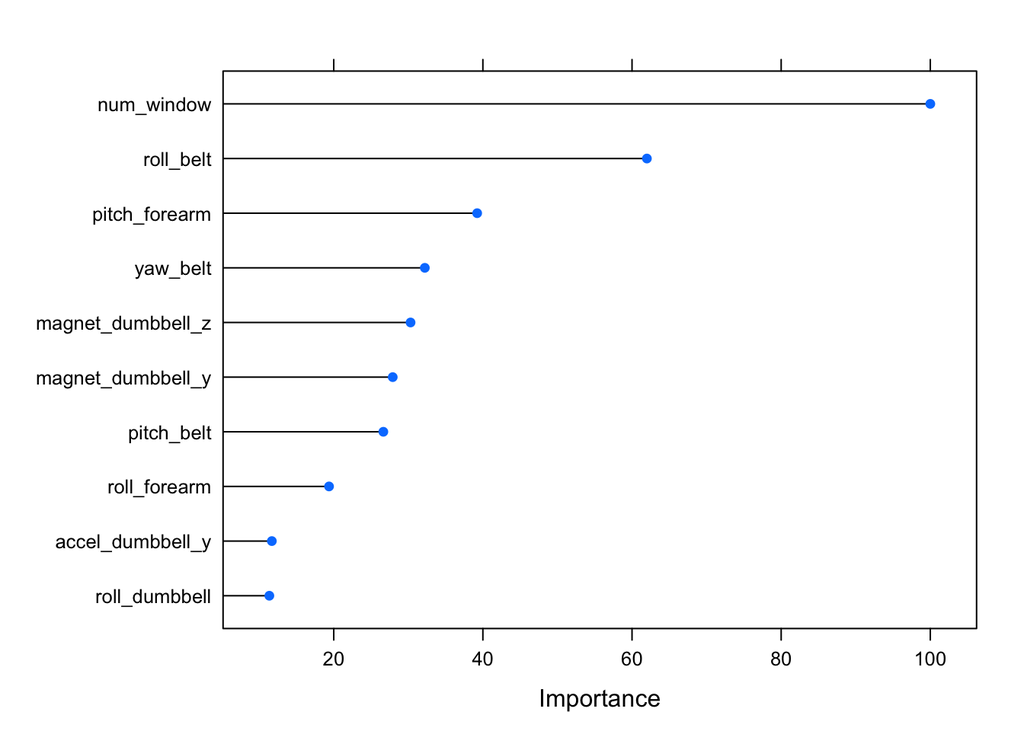

```r
plot(varImp(model_rf), top = 10)
```

## Prediction

```r
blind_rf_predict <- predict(model_rf, blind_test)

blind_rpart_predict <- predict(model_rpart, blind_test)
blind_gbm_predict <- predict(model_gbm, blind_test)

kable(cbind("randomForest" = blind_rf_predict, "gbm" = blind_gbm_predict,
            "rpart" = blind_rpart_predict),
            format = "markdown", align = 'l')
```

| randomForest | gbm | rpart |
| --- | --- | --- |
| 2 | 2 | 1 |
| 1 | 1 | 1 |
| 2 | 2 | 3 |
| 1 | 1 | 1 |
| 1 | 1 | 1 |
| 5 | 5 | 3 |
| 4 | 4 | 3 |
| 2 | 2 | 3 |
| 1 | 1 | 1 |
| 1 | 1 | 1 |
| 2 | 2 | 3 |
| 3 | 3 | 3 |
| 2 | 2 | 3 |
| 1 | 1 | 1 |
| 5 | 5 | 3 |
| 5 | 5 | 3 |
| 1 | 1 | 1 |
| 2 | 2 | 1 |
| 2 | 2 | 1 |
| 2 | 2 | 3 |

Although ‘randomForest’ has better accuracy, it produced approximately as ‘gbm’ model.